# Gaussian Processes

22. Februar 2019

## Regression und Klassifikation

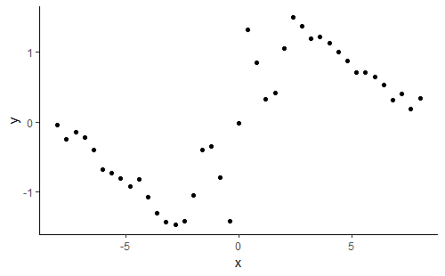

## Regression und Klassifikation

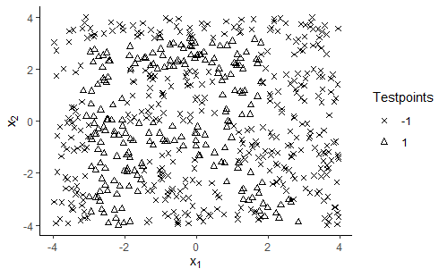

## Einführung zu Gaußschen Prozessen

- Stochastischer Prozess: \(f:\Omega \times X \rightarrow Z\), \((\omega,x) \mapsto f_x(\omega)\) wobei \(f_x(\omega)\) messbar in \(\omega\) für alle \(x\in X\).
- Anschaulich: Stochastischer Prozess ist Zufallsvariable mit Werten \(f_x\) in Funktionenraum
- Ein Gaußscher Prozess ist ein stochastischer Prozess \((f_x)_{x \in X}\) wobei für jede endliche Teilmenge \(Y \subset X\), \((f_x)_{x \in Y}\) multivariat normal verteilt ist.
- Wird charakterisiert durch \(m(x)=\mathbb{E}({f(x)})\) und \(k(x,x')=\text{Cov}(f(x),f(x'))\)  
  Im Folgenden: \(X = \mathbb{R}^d\) und \(m(x) = 0\)

## Theorie zu Regression

Gemeinsame Verteilung für Datenpunkte \((X, f(X))\) und Testpunkte: \[ \begin{pmatrix} f(X) \\ f(X_*) \end{pmatrix} \sim \mathcal{N} \left( 0, \begin{pmatrix} K(X,X) & K(X, X_*) \\ K(X_*, X) & K(X_*, X_*) \end{pmatrix} \right) \] Bedingte Verteilung: \[ f(X_*)|f(X), X, X_* \sim \mathcal{N}(\mu, \Sigma) \]

mit \[ \mu = K(X,X_*) K(X,X)^{-1} f(X) \] \[ \Sigma = K(X_*, X_*) - K(X_*, X) K(X, X)^{-1} K(X, X_*) \]

## GPR

`GPR$new(X, y, noise, cov_func)`

- R6 Klasse
- Effizienz durch Speichern und Vektorisieren
- Methoden
  - `$predict`
  - `$plot`
  - `$plot_posterior_draws`
  - `$plot_posterior_variance`
- Unterklassen für häufig auftretende Kovarianzfunktionen, die lediglich Parametereingabe erfordern

## predict Algorithmus

Annahme: \(y_i = f(x_i) + \varepsilon_i\), \(\varepsilon_i \overset{\text{iid}}{\sim} \mathcal{N}(0, \sigma_n^2)\)

Inputs: \(X\) (inputs), \(y\) (targets), \(\sigma_n^2\) (noise),  
\(K\) (covariance funtion), \(X_*\) (test input)

# 1 \(L=\text{cholesky}(K(X,X)+\sigma_n^2 I)\)  
# 2 \(\alpha=\text{solve}(L^\top,\text{solve}(L,y))\)  
# 3 \(\bar{f}(X_*)=K(X,X_*)^\top\cdot\alpha\)  
# 4 \(v=\text{solve}(L,K(X,X_*))\)  
# 5 \(\overline{\text{V}}(\bar{f}(X_*))=K(X_*,X_*)-v^\top v\)

return: \(\bar{f}(X_*)\), \(\overline{\text{V}}(f(X_*))\)

## Regression

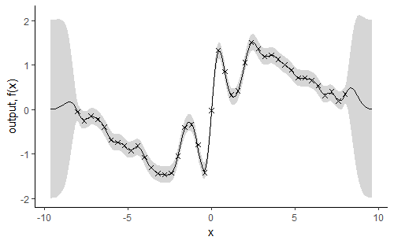

## Optimierung der Hyperparameter

Suchen Kovarianzfunktion, die beobachtete Daten am besten erklärt

Methode: Likelihood Maximierung

- Maximiere Log-Likelihood der beobachteten Daten nach der Kovarianzfunktion \(k\)
- Nutzen Newton-Methode, `optim()`

## fit()

`fit(X, y, noise, cov_names)`

- Gibt die beste Kovarianzfunktion mit optimalen Parametern zurück
- Error handling bei numerischen Problemen der Cholesky Zerlegung
- Unterschiedliche Maximierungsmethoden für verschiedene Kovarianzfunktionen

## Gewählte Kovarianzfunktion

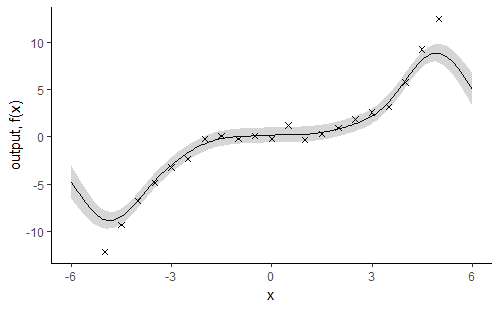

```
## The chosen covariance function is sqrexp
```

## Optimierte Kovarianzfunktion

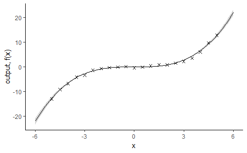

```
## The optimal covariance function is polynomial
```

## Klassifikation mit GP

- Binäres Klassifikationsproblem \(g: \mathbb{R}^D \rightarrow \{-1, +1\}\)
- Modellierung der posterior Wahrscheinlichkeit \(\mathbb{P}(g = +1|x_*)\) durch \(\pi = \mathbb{E}\left[\sigma(f_*)|y,X,x_*\right]\)
- \(f_*\) Gaußscher Prozess
- Sigmoid Funktion \(\sigma : \mathbb{R} \rightarrow [0,1]\), \(z \mapsto \frac{1}{1 + \exp(-z)}\)
- Setze \[\hat{g}(x_*) = \left\{ \begin{array}{ll} +1, & \pi \geq 0.5 \\ -1, & \, \pi < 0.5 \\ \end{array} \right. \]

## GPC

`GPC$new(X, y, cov_fun, epsilon)`

- R6 Klasse
- Methoden `$predict_class`, `$plot`
- Effizienz durch Vektorisierung

## Klassifikation

[figure not shown]

## Simulation

Framework, um Qualität von GP Methoden für verschiedene Daten zu testen

- `simulate_classification(func, limits, training_size)`
- `simulate_regression(func, limits, training_size)`
- `simulate_regression_gp(actual_cov, limits, training_size)`

## Simulation Beispiel

[figure not shown]

```
##        V1
##  Min.   :0.000000
##  1st Qu.:0.001032
##  Median :0.003208
##  Mean   :0.090275
##  3rd Qu.:0.038361
##  Max.   :1.249635
```